# project_population_binary

## BINARY CLASSIFICATION OF TRACK POPULARITY

### Importing imp. libraries

```python
import pandas as pd
import matplotlib.pyplot as plt
import seaborn as sns
import numpy as np
from sklearn.model_selection import train_test_split, GridSearchCV
from sklearn.preprocessing import LabelEncoder
from sklearn.tree import DecisionTreeClassifier, plot_tree
from sklearn.ensemble import RandomForestClassifier
from sklearn.impute import SimpleImputer
from sklearn.metrics import accuracy_score, classification_report, confusion_matrix
from sklearn.tree import DecisionTreeClassifier, export_text, plot_tree
from sklearn.preprocessing import StandardScaler
import xgboost as xgb
from tensorflow.keras.models import Sequential
from tensorflow.keras.layers import Dense
from tensorflow.keras.callbacks import EarlyStopping
from tensorflow.keras.metrics import AUC
from tensorflow.keras.optimizers import Adam
from sklearn.metrics import (
    precision_score, recall_score, f1_score,
    roc_auc_score, confusion_matrix, classification_report
)
```

```python
# Loading Dataset
spotify_df = pd.read_csv(r"C:\Users\alekh\Downloads\SpotifyFeatures.csv")
```

```python
# Columns
spotify_df.columns
```

```
Index(['genre', 'artist_name', 'track_name', 'track_id', 'popularity',
       'acousticness', 'danceability', 'duration_ms', 'energy',
       'instrumentalness', 'key', 'liveness', 'loudness', 'mode',
       'speechiness', 'tempo', 'time_signature', 'valence'],
      dtype='object')
```

### Data Cleaning

```python
# Duplicate Track ID count
count = spotify_df['track_id'].value_counts()
num_duplicated_ids = (count > 1).sum()
print("Number of unique track ID values that are duplicated:", num_duplicated_ids)
```

```
Number of unique track ID values that are duplicated: 35124
```

```python
# Inspect a Duplicated Track
first_duplicate_id = spotify_df[spotify_df.duplicated(subset='track_id', keep='first')]['track_id'].iloc[0]
print("First duplicated track_id:", first_duplicate_id)
spotify_df[spotify_df['track_id'] == first_duplicate_id]
```

```
First duplicated track_id: 6iOvnACn4ChlAw4lWUU4dd
```

|  | genre | artist_name | track_name | track_id | popularity | acousticness | danceability | duration_ms | energy | instrumentalness | key | liveness | loudness | mode | speechiness | tempo | time_signature | valence |
| --- | --- | --- | --- | --- | --- | --- | --- | --- | --- | --- | --- | --- | --- | --- | --- | --- | --- | --- |
| 257 | R&B | Doja Cat | Go To Town | 6iOvnACn4ChlAw4lWUU4dd | 64 | 0.0716 | 0.71 | 217813 | 0.71 | 0.000001 | C | 0.206 | -2.474 | Major | 0.0579 | 169.944 | 4/4 | 0.7 |
| 1348 | Alternative | Doja Cat | Go To Town | 6iOvnACn4ChlAw4lWUU4dd | 64 | 0.0716 | 0.71 | 217813 | 0.71 | 0.000001 | C | 0.206 | -2.474 | Major | 0.0579 | 169.944 | 4/4 | 0.7 |
| 77710 | Children’s Music | Doja Cat | Go To Town | 6iOvnACn4ChlAw4lWUU4dd | 64 | 0.0716 | 0.71 | 217813 | 0.71 | 0.000001 | C | 0.206 | -2.474 | Major | 0.0579 | 169.944 | 4/4 | 0.7 |
| 93651 | Indie | Doja Cat | Go To Town | 6iOvnACn4ChlAw4lWUU4dd | 64 | 0.0716 | 0.71 | 217813 | 0.71 | 0.000001 | C | 0.206 | -2.474 | Major | 0.0579 | 169.944 | 4/4 | 0.7 |
| 113770 | Pop | Doja Cat | Go To Town | 6iOvnACn4ChlAw4lWUU4dd | 64 | 0.0716 | 0.71 | 217813 | 0.71 | 0.000001 | C | 0.206 | -2.474 | Major | 0.0579 | 169.944 | 4/4 | 0.7 |

```python
# Clean Duplicated Tracks
spotify_df= spotify_df.drop_duplicates(subset=['track_id'])
count = spotify_df['track_id'].value_counts()
num_duplicated_ids = (count > 1).sum()
print("Number of unique tracks that are duplicated after cleaning:", num_duplicated_ids)
```

```
Number of unique tracks that are duplicated after cleaning: 0
```

### EDA

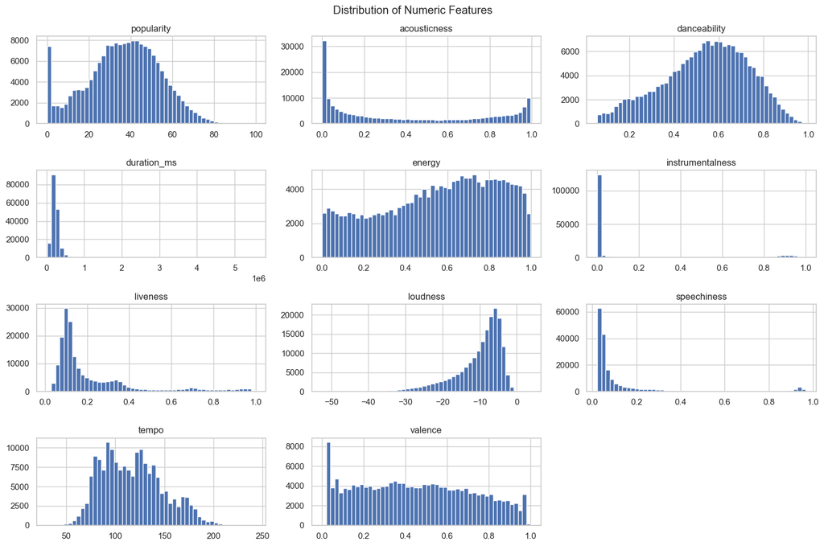

```python
# Data Visualisation
sns.set(style='whitegrid')

# Select Numeric Columns
df_numeric = spotify_df.select_dtypes(include='number')

# Plot Histograms
df_numeric.hist(bins=50, figsize=(15, 10))
plt.suptitle('Distribution of Numeric Features')
plt.tight_layout()
plt.show()
```

We removed out songs with zero popularity as it does not signify any measurable value from audience and categorized the remaining tracks into two classes:

- **Low popularity** (1–40)
- **High popularity** (41–80)

```python
spotify_df = spotify_df[spotify_df['popularity'] != 0]

#Popularity col. classification
def popularity_class(popularity):
    if 1 <= popularity <= 40:
        return 'low'
    elif 41 <= popularity <= 80:
        return 'high'
    else:
        return None  #values outside 1-80

spotify_df['popularity_class'] = spotify_df['popularity'].apply(popularity_class)

#Drop rows with popularity outside 1–80
spotify_df = spotify_df[spotify_df['popularity_class'].notnull()]
```

### Feature Selection & Data Preparation

- We selected 10 audio features from Spotify tracks to predict song popularity.
- The dataset was split into training and testing sets (80/20 split), and all features were standardized to ensure equal contribution during model training.

```python
features = [
    'acousticness', 'danceability', 'duration_ms', 'energy',
    'instrumentalness', 'liveness', 'loudness', 'speechiness',
    'tempo', 'valence'
]


X = spotify_df[features]
y = spotify_df['popularity_class']

X_train, X_test, y_train, y_test = train_test_split(
    X, y, test_size=0.2, random_state=42
)

scaler = StandardScaler()
X_train_scaled = scaler.fit_transform(X_train)
X_test_scaled = scaler.transform(X_test)

print("Training set size:", X_train_scaled.shape)
print("Test set size:", X_test_scaled.shape)
```

```
Training set size: (136090, 10)
Test set size: (34023, 10)
```

### Unpruned Decision Tree

```
Unpruned Decision Tree Accuracy: 0.6209328983334803
              precision    recall  f1-score   support

        high       0.56      0.58      0.57     14816
         low       0.67      0.65      0.66     19207

    accuracy                           0.62     34023
   macro avg       0.62      0.62      0.62     34023
weighted avg       0.62      0.62      0.62     34023
```

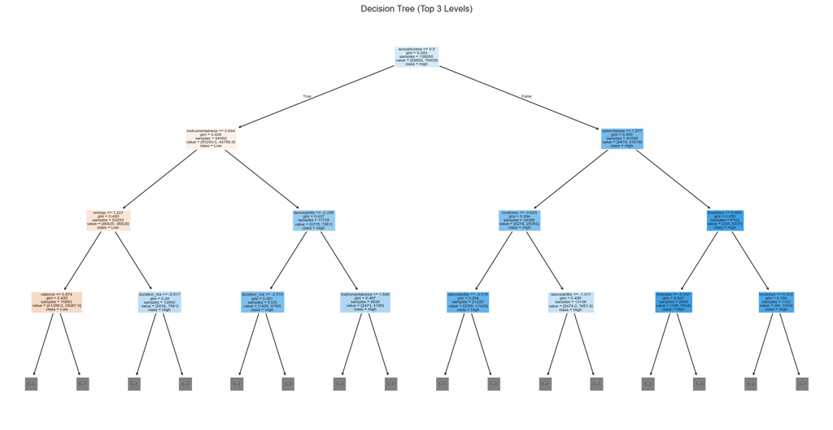

```
|--- acousticness <= 0.80
|   |--- instrumentalness <= 0.69
|   |   |--- energy <= 1.22
|   |   |   |--- valence <= 0.87
|   |   |   |   |--- liveness <= 2.12
|   |   |   |   |   |--- duration_ms <= 0.21
|   |   |   |   |   |   |--- loudness <= -0.07
|   |   |   |   |   |   |   |--- duration_ms <= -0.99
|   |   |   |   |   |   |   |   |--- liveness <= -0.40
|   |   |   |   |   |   |   |   |   |--- valence <= 0.51
|   |   |   |   |   |   |   |   |   |   |--- tempo <= 1.30
|   |   |   |   |   |   |   |   |   |   |   |--- truncated branch of depth 10
|   |   |   |   |   |   |   |   |   |   |--- tempo >  1.30
|   |   |   |   |   |   |   |   |   |   |   |--- truncated branch of depth 4
|   |   |   |   |   |   |   |   |   |--- valence >  0.51
|   |   |   |   |   |   |   |   |   |   |--- tempo <= 1.78
|   |   |   |   |   |   |   |   |   |   |   |--- class: low
|   |   |   |   |   |   |   |   |   |   |--- tempo >  1.78
|   |   |   |   |   |   |   |   |   |   |   |--- truncated branch of depth 2
|   |   |   |   |   |   |   |   |--- liveness >  -0.40
|   |   |   |   |   |   |   |   |   |--- speechiness <= -0.48
|   |   |   |   |   |   |   |   |   |   |--- duration_ms <= -1.10
|   |   |   |   |   |   |   |   |   |   |   |--- class: high
|   |   |   |   |   |   |   |   |   |   |--- duration_ms >  -1.10
|   |   |   |   |   |   |   |   |   |   |   |--- class: low
|   |   |   |   |   |   |   |   |   |--- speechiness >  -0.48
|   |   |   |   |   |   |   |   |   |   |--- speechiness <= 2.35
```

```python
tree_model = DecisionTreeClassifier(random_state=42)
tree_model.fit(X_train_scaled, y_train)

# Predict on test set
y_pred_dt = tree_model.predict(X_test_scaled)

# Evaluate
print("Unpruned Decision Tree Accuracy:", accuracy_score(y_test, y_pred_dt))
print(classification_report(y_test, y_pred_dt))

# View of tree depth=3
plt.figure(figsize=(20,10))
plot_tree(tree_model, feature_names=X_train.columns,
          class_names=['Low', 'High'],
          filled=True, max_depth=3)
plt.title('Decision Tree (Top 3 Levels)')
plt.show()

# Printing only first 1500
tree_summary = export_text(tree_model, feature_names=list(X_train.columns))
print(tree_summary[:1500])
```

```python
# Tuning tree size using cross-validation
param_grid = {'max_leaf_nodes': range(2, 20)}
grid_search_dt = GridSearchCV(DecisionTreeClassifier(random_state=42),
                              param_grid=param_grid,
                              cv=5, scoring='accuracy')

grid_search_dt.fit(X_train_scaled, y_train)
pruned_tree = grid_search_dt.best_estimator_
y_pred_pruned = pruned_tree.predict(X_test_scaled)

# Evaluate
print("Pruned Decision Tree Accuracy:", accuracy_score(y_test, y_pred_pruned))
print(classification_report(y_test, y_pred_pruned))

# Plot pruned tree
plt.figure(figsize=(15,10))
plot_tree(pruned_tree, feature_names=X_train.columns,
          class_names=['Low', 'High'],
          filled=True)
plt.title('Pruned Decision Tree')
plt.show()

print(f"Best Tree Size (max_leaf_nodes): {grid_search_dt.best_params_['max_leaf_nodes']}")
```

[output not shown]

[figure not shown]

[output not shown]

```python
# Tuning tree size using cross-validation
param_grid = {
    'max_depth': [3, 4, 5, 6, None],
    'min_samples_split': [2, 5, 10],
    'min_samples_leaf': [1, 2, 4],
    'max_leaf_nodes': [None, 5, 10, 15],
    'criterion': ['gini', 'entropy']
}

grid_search_dt = GridSearchCV(DecisionTreeClassifier(random_state=42),
                              param_grid=param_grid,
                              cv=5, scoring='accuracy')

grid_search_dt.fit(X_train_scaled, y_train)
pruned_tree = grid_search_dt.best_estimator_
y_pred_pruned = pruned_tree.predict(X_test_scaled)

# Evaluate
print("Pruned Decision Tree Accuracy:", accuracy_score(y_test, y_pred_pruned))
print(classification_report(y_test, y_pred_pruned))

# Plot pruned tree
plt.figure(figsize=(15,10))
plot_tree(pruned_tree, feature_names=X_train.columns,
          class_names=['Low', 'High'],
          filled=True)
plt.title('Pruned Decision Tree')
plt.show()
```

[output not shown]

```python
print("Best Parameters Found:")
print(grid_search_dt.best_params_)
```

```
Best Parameters Found:
{'criterion': 'gini', 'max_depth': 6, 'max_leaf_nodes': None, 'min_samples_leaf': 1, 'min_samples_split': 10}
```

### Pruned Decision Tree

[figure not shown]

```python
plt.figure(figsize=(20, 12))
plot_tree(
    pruned_tree,
    feature_names=X_train.columns,
    class_names=['Low', 'High'],
    filled=True,
    rounded=True,
    fontsize=10
)

plt.title('Pruned Decision Tree')
plt.savefig('Pruned_Decision_Tree_HighRes.png', dpi=600, bbox_inches='tight')
plt.show()
```

### Random Forest

```
Fitting 5 folds for each of 54 candidates, totalling 270 fits
Tuned Random Forest Accuracy: 0.7079034770596361
              precision    recall  f1-score   support

        high       0.66      0.68      0.67     14816
         low       0.75      0.73      0.74     19207

    accuracy                           0.71     34023
   macro avg       0.70      0.70      0.70     34023
weighted avg       0.71      0.71      0.71     34023

Best Parameters: {'max_depth': 20, 'min_samples_leaf': 2, 'min_samples_split': 5, 'n_estimators': 200}
```

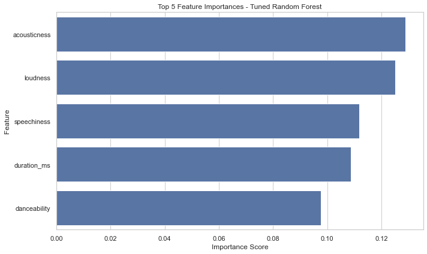

```python
param_grid = {
    'n_estimators': [100, 200],
    'max_depth': [None, 10, 20],
    'min_samples_split': [2, 5, 10],
    'min_samples_leaf': [1, 2, 4]
}

rf_grid = GridSearchCV(RandomForestClassifier(random_state=42),
                       param_grid, cv=5, scoring='accuracy',
                       n_jobs=-1, verbose=1)

rf_grid.fit(X_train_scaled, y_train)

best_rf = rf_grid.best_estimator_
y_pred_rf = best_rf.predict(X_test_scaled)

print("Tuned Random Forest Accuracy:", accuracy_score(y_test, y_pred_rf))
print(classification_report(y_test, y_pred_rf))
print("Best Parameters:", rf_grid.best_params_)

importances = pd.Series(best_rf.feature_importances_, index=X_train.columns).sort_values(ascending=False)
top5_importances = importances.head(5)

plt.figure(figsize=(10,6))
sns.barplot(x=top5_importances, y=top5_importances.index)
plt.title('Top 5 Feature Importances - Tuned Random Forest')
plt.xlabel('Importance Score')
plt.ylabel('Feature')
plt.tight_layout()
plt.show()
```

The best parameters for random forest are:

- the number of trees are 200
- maximum depth of each tree is 20
- The minimum number of samples required to be at a leaf node are 2
- the minimum number of samples required to split an internal node are 5

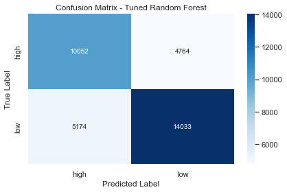

```python
cm = confusion_matrix(y_test, y_pred_rf, labels=['high', 'low'])

# Plot confusion matrix heatmap
plt.figure(figsize=(6, 4))
sns.heatmap(cm, annot=True, fmt='d', cmap='Blues',
            xticklabels=['high', 'low'], yticklabels=['high', 'low'])
plt.title('Confusion Matrix - Tuned Random Forest')
plt.xlabel('Predicted Label')
plt.ylabel('True Label')
plt.tight_layout()
plt.show()
```

The model correctly predicted over 10,000 high popularity songs and 14,000 low popularity songs. It misclassified 4,764 high and 5,174 low popularity songs, indicating fairly balanced but slightly better performance on the low class.

```python
print("Summary of Model Accuracies:")
print(f"- Unpruned Decision Tree Accuracy: {accuracy_score(y_test, y_pred_dt):.4f}")
print(f"- Pruned Decision Tree Accuracy: {accuracy_score(y_test, y_pred_pruned):.4f}")
print(f"- Random Forest Accuracy: {accuracy_score(y_test, y_pred_rf):.4f}")

if accuracy_score(y_test, y_pred_rf) > accuracy_score(y_test, y_pred_pruned):
    print("\nRandom Forest outperformed both Decision Tree versions.")
else:
    print("\nPruned Decision Tree performed competitively with Random Forest.")
```

```
Summary of Model Accuracies:
- Unpruned Decision Tree Accuracy: 0.6209
- Pruned Decision Tree Accuracy: 0.6708
- Random Forest Accuracy: 0.7079

Random Forest outperformed both Decision Tree versions.
```

### XG Boost

[output not shown]

```
XGBoost Accuracy: 0.6979690209564119
              precision    recall  f1-score   support

        high       0.65      0.67      0.66     14816
         low       0.74      0.72      0.73     19207

    accuracy                           0.70     34023
   macro avg       0.69      0.70      0.69     34023
weighted avg       0.70      0.70      0.70     34023
```

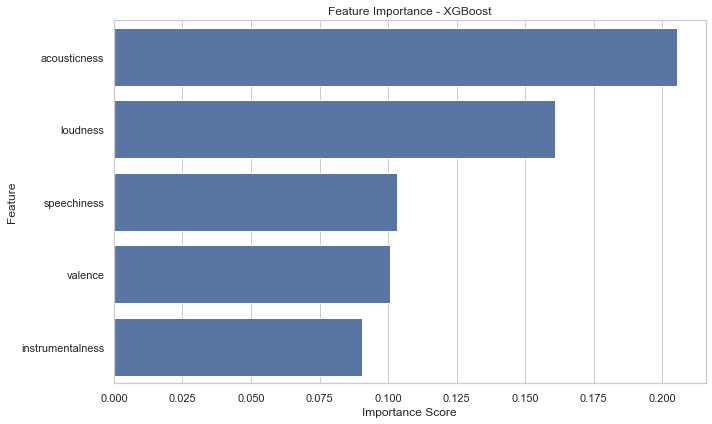

```python
le = LabelEncoder()
y_train_encoded = le.fit_transform(y_train)
y_test_encoded = le.transform(y_test)


xgb_model = xgb.XGBClassifier(n_estimators=200, max_depth=4, learning_rate=0.1, use_label_encoder=False, eval_metric='logloss', random_state=42)
xgb_model.fit(X_train_scaled, y_train_encoded)

y_pred_xgb = xgb_model.predict(X_test_scaled)

print("XGBoost Accuracy:", accuracy_score(y_test_encoded, y_pred_xgb))
print(classification_report(y_test_encoded, y_pred_xgb, target_names=le.classes_))

#Feature Importance Plot
xgb_importances = pd.Series(xgb_model.feature_importances_, index=X_train.columns).sort_values(ascending=False)
top5_xgb_importances = xgb_importances.head(5)

plt.figure(figsize=(10,6))
sns.barplot(x=top5_xgb_importances, y=top5_xgb_importances.index)
plt.title('Feature Importance - XGBoost')
plt.xlabel('Importance Score')
plt.ylabel('Feature')
plt.tight_layout()
plt.show()
```

```python
param_grid = {
    'n_estimators': [100, 200],
    'max_depth': [3, 4, 5],
    'learning_rate': [0.05, 0.1, 0.2],
    'subsample': [0.8, 1]
}

xgb_clf = xgb.XGBClassifier(use_label_encoder=False, eval_metric='logloss', random_state=42)

# Grid Search
grid_search = GridSearchCV(estimator=xgb_clf, param_grid=param_grid,
                           scoring='accuracy', cv=5, verbose=1, n_jobs=-1)

grid_search.fit(X_train_scaled, y_train_encoded)

# Best model
print("Best parameters found:", grid_search.best_params_)
print("Best cross-validation score:", grid_search.best_score_)

# Evaluate best model
best_model = grid_search.best_estimator_
y_pred_best = best_model.predict(X_test_scaled)
print("Test Accuracy:", accuracy_score(y_test_encoded, y_pred_best))
print(classification_report(y_test_encoded, y_pred_best, target_names=le.classes_))
```

```
Fitting 5 folds for each of 36 candidates, totalling 180 fits
```

[output not shown]

```
Best parameters found: {'learning_rate': 0.1, 'max_depth': 5, 'n_estimators': 200, 'subsample': 0.8}
Best cross-validation score: 0.701212432948784
Test Accuracy: 0.7021426681950446
              precision    recall  f1-score   support

        high       0.65      0.68      0.66     14816
         low       0.74      0.72      0.73     19207

    accuracy                           0.70     34023
   macro avg       0.70      0.70      0.70     34023
weighted avg       0.70      0.70      0.70     34023
```

The best parameters for XGB Boost are:

- number of trees are 200
- learning rate is 0.1
- maximum depth of each tree is 5
- subsample(fraction of the training data used for each tree) is 0.8